# Survival Analysis

### Maria Ines Aran - October 2019

# Survival analysis of heart attack

This R script is part of [Statistical Analysis with R for Public Health(Imperial College London)](https://www.coursera.org/specializations/statistical-analysis-r-public-health?).

The data simulates Electronic Medical Records from UK hospitals.

```r
# Libraries
library(survival)
library(knitr)
library(ggplot2)
library(survminer)
library(dplyr)
options(scipen=999) # do not use scientific notation

# Read dataset
setwd("~/Documents/cursos/Health_statistics_Imperial_college")
g <- read.csv('survival_df.csv', header = TRUE ,  sep = ',')

# Set data type
gender <- as.factor(g[,'gender'])
fu_time <- g[,'fu_time']
death <- g[,'death']
```

# Data description

Data contains observations of 1000 patients, 49.2% of them died.

```r
dim(g)
prop.table(table(g$death))
summary(g$fu_time)
g %>% group_by(death) %>% summarize(mean=mean(fu_time))
```

[output not shown]

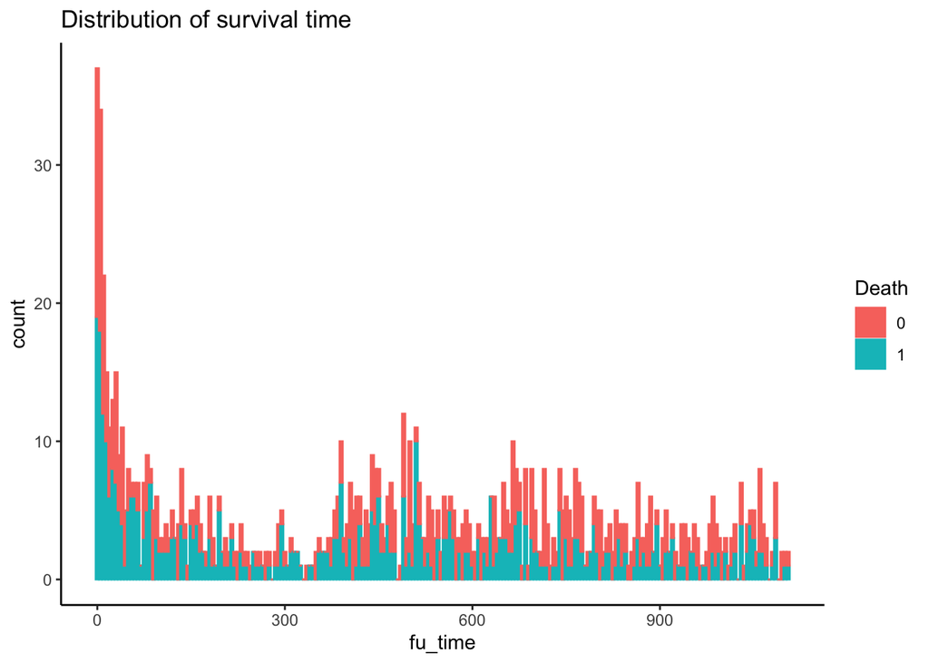

```r
ggplot(g, aes(x=fu_time, color=factor(death), fill=factor(death))) +
  geom_histogram(binwidth = 5) +
  labs(x='fu_time',
       title = 'Distribution of survival time',
       color = 'Death',
       fill = 'Death') +
  theme_classic()
```

# Kaplan - Meier plots

Kaplan and Meier plots show the estimation of the probability of surviving at least to any given time. It is the survival function.

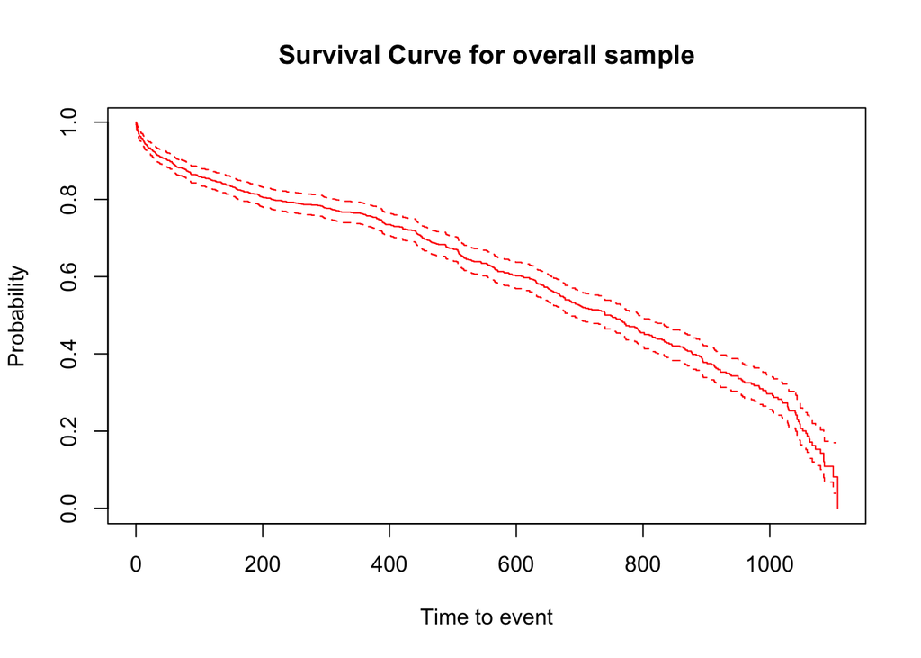

```r
# Fit Kaplan - Meier survival curve
km_fit <-survfit(Surv(fu_time,death) ~ 1) # 1 It's the intercept

# Survival
plot(km_fit,
     col = 'red',
     main = 'Survival Curve for overall sample',
     xlab = 'Time to event',
     ylab = 'Probability')
```

# Kaplan-Meier curves by gender

The survival curves for female and male are plotted.

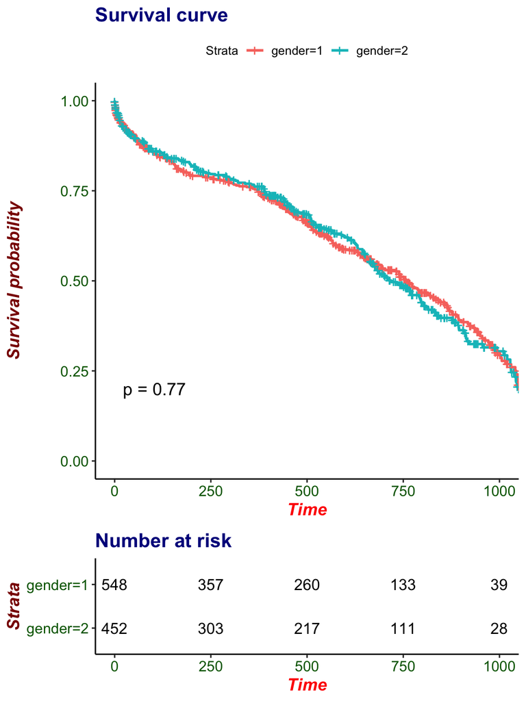

```r
# Survival object: Define ime to event and event
surv_object <- Surv(time = g$fu_time, event = g$death)

# Fit survival curve
fit1 <- do.call(survfit,list(formula = surv_object ~ gender, data = g))

# Plot
p <- ggsurvplot(fit1,
             pval = TRUE,
             risk.table = TRUE,
             title = 'Survival curve')
# Plot aesthics
p + theme_survminer(font.main = c(16, "bold", "darkblue"),
    font.submain = c(15, "bold.italic", "purple"),
    font.caption = c(14, "plain", "orange"),
    font.x = c(14, "bold.italic", "red"),
    font.y = c(14, "bold.italic", "darkred"),
    font.tickslab = c(12, "plain", "darkgreen"))
```

```r
# Risk table aesthics
p$table <- p$table + theme_cleantable()
```

The life table shows for each point in time the number of patients in the study at time t, the number of patients that died at time t and the survival probability at every given time.

```r
# Full table
summary(km_fit, times = c(1:10))
```

```
## Call: survfit(formula = Surv(fu_time, death) ~ 1)
##
##  time n.risk n.event survival std.err lower 95% CI upper 95% CI
##     1    992      12    0.988 0.00346        0.981        0.995
##     2    973       7    0.981 0.00435        0.972        0.989
##     3    963       5    0.976 0.00489        0.966        0.985
##     4    954       6    0.970 0.00546        0.959        0.980
##     5    945       5    0.964 0.00590        0.953        0.976
##     6    938       1    0.963 0.00598        0.952        0.975
##     7    933       1    0.962 0.00606        0.951        0.974
##     8    929       4    0.958 0.00638        0.946        0.971
##     9    924       0    0.958 0.00638        0.946        0.971
##    10    924       1    0.957 0.00646        0.945        0.970
```

To test if there is an statistically significant difference between the groups, we can run a log-rank test. The null hypothesis is that there are no differences between the proportion of deaths between group’s populations.

```r
# Logrank test to compare differences between survival curves
survdiff(Surv(fu_time,death) ~ gender, rho = 0) #rho=0 The Mantel-Haenszel test
```

```
## Call:
## survdiff(formula = Surv(fu_time, death) ~ gender, rho = 0)
##
##            N Observed Expected (O-E)^2/E (O-E)^2/V
## gender=1 548      268      271    0.0365     0.082
## gender=2 452      224      221    0.0448     0.082
##
##  Chisq= 0.1  on 1 degrees of freedom, p= 0.8
```

In this case as p-value is greater than 0.05, we cannot reject the null hypothesis so we conclude there are no reasons to believe that there differences in mortality rate between men and women.

## Survival curves by age

We divided the sample between two groups: young(<65) and old(>=65). We calculate the survival functions for each of them and find out if the difference is statistically significant.

```r
# Differnces between survival curves by age
age_binary <- ifelse(g$age < 65, 1, 0)

# Logrank test to compare differences bewteen survival curves
survdiff(Surv(fu_time,death) ~ age_binary, rho = 0)
```

```
## Call:
## survdiff(formula = Surv(fu_time, death) ~ age_binary, rho = 0)
##
##                N Observed Expected (O-E)^2/E (O-E)^2/V
## age_binary=0 885      474      425      5.65      41.7
## age_binary=1 115       18       67     35.85      41.7
##
##  Chisq= 41.7  on 1 degrees of freedom, p= 0.0000000001
```

Interpretation: H0 is that there are no differences between the proportion of death between people age < 65 and age > 65. H0: Populationprop_65 - Populationprop_greater65 = 0

# Cox model

## Cox model with continuous variable

Hazard function maths: https://data.princeton.edu/wws509/notes/c7s1

The cox model or cox proportional hazard model, predicts the time to event based on explanatory features.

- Hazard risk: Risk of death at a given moment in time. Hazards change over time.
- Hazard function: The way hazard risk changes over time.
- Proportional hazard: Comparing one group’s hazard function against other group hazard function. For example, the elderly’s hazard is 2 times the younger’s hazard. Doesn’t matter the shape of the curve, just the relationship between the groups.
- Hazard ratio: One hazard divided by the other. For example Hazard ratio for females, how much likely is it that a woman will die compared to men?

```r
cox <- coxph(Surv(fu_time,death)~ age, data = g)
summary(cox)
```

```
## Call:
## coxph(formula = Surv(fu_time, death) ~ age, data = g)
##
##   n= 1000, number of events= 492
##
##         coef exp(coef) se(coef)     z            Pr(>|z|)
## age 0.056005  1.057602 0.005193 10.78 <0.0000000000000002 ***
## ---
## Signif. codes:  0 '***' 0.001 '**' 0.01 '*' 0.05 '.' 0.1 ' ' 1
##
##     exp(coef) exp(-coef) lower .95 upper .95
## age     1.058     0.9455     1.047     1.068
##
## Concordance= 0.651  (se = 0.013 )
## Likelihood ratio test= 138  on 1 df,   p=<0.0000000000000002
## Wald test            = 116.3  on 1 df,   p=<0.0000000000000002
## Score (logrank) test = 115.7  on 1 df,   p=<0.0000000000000002
```

Output: - Coef and exp(coef) are log hazard ratio and hazard ratio (exponential). Exp coeficient for age is 1.05: It means that at any given time for each year increase in age the hazard ratio increases by 5.7%. Ergo the older you are the greater chances to died. Every year you get older, the hazard ratio increases almost 6%. - Standard error(se) - z value is like t in linear regression and it is converted to p-value. - p-value < 0.05 statistical significant, - Lower.95 and upper .95 is the confidence interval for age. - Concordance: C-Statistics, discrimination. > 0.5 is good. Fraction of pairs of patients whereas the patient with the highest survival time has the highest survival probability as predicted by the model. - Rsquare: Proportion in the outcome explained by the model

Comparisons against a plain model (without any x feature): - Likelyhood test - Wald test - Score (logrank) if p-values are p< 0.05 is statistically significant. Better than the plain model.

## Cox model with categorical feature

```r
# Convert the variable to factor
ethnicgroup <- factor(g[,'ethnicgroup'])
fu_time <- g[,'fu_time']
death <- g[,'death']

cox <- coxph(Surv(fu_time,death) ~ ethnicgroup)
summary(cox)
```

```
## Call:
## coxph(formula = Surv(fu_time, death) ~ ethnicgroup)
##
##   n= 957, number of events= 471
##    (43 observations deleted due to missingness)
##
##                  coef exp(coef) se(coef)      z Pr(>|z|)
## ethnicgroup2 -0.06428   0.93774  0.32000 -0.201  0.84078
## ethnicgroup3 -1.19586   0.30244  0.41108 -2.909  0.00362 **
## ethnicgroup9  0.07394   1.07674  0.35706  0.207  0.83596
## ---
## Signif. codes:  0 '***' 0.001 '**' 0.01 '*' 0.05 '.' 0.1 ' ' 1
##
##              exp(coef) exp(-coef) lower .95 upper .95
## ethnicgroup2    0.9377     1.0664    0.5008    1.7558
## ethnicgroup3    0.3024     3.3064    0.1351    0.6769
## ethnicgroup9    1.0767     0.9287    0.5348    2.1679
##
## Concordance= 0.516  (se = 0.006 )
## Likelihood ratio test= 12.99  on 3 df,   p=0.005
## Wald test            = 8.55  on 3 df,   p=0.04
## Score (logrank) test = 9.61  on 3 df,   p=0.02
```

Interpretation: There are missing values The ethnicgroup2 (black) has a hazard ratio of 0.93, meaning 7% less chances of dying compared to the ethnicgroup 1 (white). But it is not statistically significant and the confidence interval goes from 0.5 to 1.75, so there is no evidence of differences in hazard ratios between black and white people.

### What to do with the missings?

There are 43 that do not belong to any ethnic group. We can create ethincgroup = unknown

```r
levels(ethnicgroup) <- c(levels(ethnicgroup), '8') # add 8 to the levels
ethnicgroup[is.na(ethnicgroup)] <- '8' # assign 8 to NA

# Cox model
cox <- coxph(Surv(fu_time,death) ~ ethnicgroup)
summary(cox)
```

```
## Call:
## coxph(formula = Surv(fu_time, death) ~ ethnicgroup)
##
##   n= 1000, number of events= 492
##
##                  coef exp(coef) se(coef)      z Pr(>|z|)
## ethnicgroup2 -0.06573   0.93638  0.31999 -0.205  0.83725
## ethnicgroup3 -1.19368   0.30310  0.41107 -2.904  0.00369 **
## ethnicgroup9  0.08160   1.08502  0.35706  0.229  0.81923
## ethnicgroup8 -0.02353   0.97675  0.22363 -0.105  0.91621
## ---
## Signif. codes:  0 '***' 0.001 '**' 0.01 '*' 0.05 '.' 0.1 ' ' 1
##
##              exp(coef) exp(-coef) lower .95 upper .95
## ethnicgroup2    0.9364     1.0679    0.5001    1.7532
## ethnicgroup3    0.3031     3.2992    0.1354    0.6784
## ethnicgroup9    1.0850     0.9216    0.5389    2.1846
## ethnicgroup8    0.9767     1.0238    0.6301    1.5140
##
## Concordance= 0.518  (se = 0.008 )
## Likelihood ratio test= 12.95  on 4 df,   p=0.01
## Wald test            = 8.53  on 4 df,   p=0.07
## Score (logrank) test = 9.58  on 4 df,   p=0.05
```

Done by [Maria Ines Aran](https://github.com/aranmariaines/)

*aranmariaines@gmail.com*